# linreg1

### Linear Regression Introduction

Load the dataset. This is a VERY basic dataset with characteristics of cars from the mid-1970s.

```r
cars = mtcars #using default mtcars R dataset
```

Structure and Summary

```r
str(cars)
```

```
'data.frame':   32 obs. of  11 variables:
 $ mpg : num  21 21 22.8 21.4 18.7 18.1 14.3 24.4 22.8 19.2 ...
 $ cyl : num  6 6 4 6 8 6 8 4 4 6 ...
 $ disp: num  160 160 108 258 360 ...
 $ hp  : num  110 110 93 110 175 105 245 62 95 123 ...
 $ drat: num  3.9 3.9 3.85 3.08 3.15 2.76 3.21 3.69 3.92 3.92 ...
 $ wt  : num  2.62 2.88 2.32 3.21 3.44 ...
 $ qsec: num  16.5 17 18.6 19.4 17 ...
 $ vs  : num  0 0 1 1 0 1 0 1 1 1 ...
 $ am  : num  1 1 1 0 0 0 0 0 0 0 ...
 $ gear: num  4 4 4 3 3 3 3 4 4 4 ...
 $ carb: num  4 4 1 1 2 1 4 2 2 4 ...
```

```r
summary(cars)
```

```
      mpg             cyl             disp             hp
 Min.   :10.40   Min.   :4.000   Min.   : 71.1   Min.   : 52.0
 1st Qu.:15.43   1st Qu.:4.000   1st Qu.:120.8   1st Qu.: 96.5
 Median :19.20   Median :6.000   Median :196.3   Median :123.0
 Mean   :20.09   Mean   :6.188   Mean   :230.7   Mean   :146.7
 3rd Qu.:22.80   3rd Qu.:8.000   3rd Qu.:326.0   3rd Qu.:180.0
 Max.   :33.90   Max.   :8.000   Max.   :472.0   Max.   :335.0
      drat             wt             qsec             vs
 Min.   :2.760   Min.   :1.513   Min.   :14.50   Min.   :0.0000
 1st Qu.:3.080   1st Qu.:2.581   1st Qu.:16.89   1st Qu.:0.0000
 Median :3.695   Median :3.325   Median :17.71   Median :0.0000
 Mean   :3.597   Mean   :3.217   Mean   :17.85   Mean   :0.4375
 3rd Qu.:3.920   3rd Qu.:3.610   3rd Qu.:18.90   3rd Qu.:1.0000
 Max.   :4.930   Max.   :5.424   Max.   :22.90   Max.   :1.0000
       am              gear            carb
 Min.   :0.0000   Min.   :3.000   Min.   :1.000
 1st Qu.:0.0000   1st Qu.:3.000   1st Qu.:2.000
 Median :0.0000   Median :4.000   Median :2.000
 Mean   :0.4062   Mean   :3.688   Mean   :2.812
 3rd Qu.:1.0000   3rd Qu.:4.000   3rd Qu.:4.000
 Max.   :1.0000   Max.   :5.000   Max.   :8.000
```

```r
# This next function shows first six rows of data (can be useful)
head(cars)
```

```
                   mpg cyl disp  hp drat    wt  qsec vs am gear carb
Mazda RX4         21.0   6  160 110 3.90 2.620 16.46  0  1    4    4
Mazda RX4 Wag     21.0   6  160 110 3.90 2.875 17.02  0  1    4    4
Datsun 710        22.8   4  108  93 3.85 2.320 18.61  1  1    4    1
Hornet 4 Drive    21.4   6  258 110 3.08 3.215 19.44  1  0    3    1
Hornet Sportabout 18.7   8  360 175 3.15 3.440 17.02  0  0    3    2
Valiant           18.1   6  225 105 2.76 3.460 20.22  1  0    3    1
```

### Predictive Modeling Process

CRISP-DM (Cross-Industry Standard Process for Data Mining) is a popular approach to build predictive models.

Steps:

1. Gain problem/business understanding (Intuition)  
2. Gain data understanding  
3. Prepare (clean) data –> Data should be consistent and technically correct  
4. Build predictive model(s)  
5. Evaluate model(s)  
6. Deploy model for use

### Problem Understanding

Our objective is to use car characteristics to predict gas mileage.

### Data Understanding

Where is this data from? What context? Any limitations to its use?

### Data Preparation

Consistent and technically correct data should have the following characteristics:

- Data should have no missingness (or missingness should be explained)
- Data should be tabular
- Data should be in correct types
- Outliers in data should be eliminated or explained
- Logical inconsistencies should be addressed

### Visualization

Let’s visualize the data.

[figure not shown]

```r
ggpairs(cars)
```

More than eight or ten variables is hard to view at once, so view subsets of variables. What does the “1” in the code below mean and why are we using it?

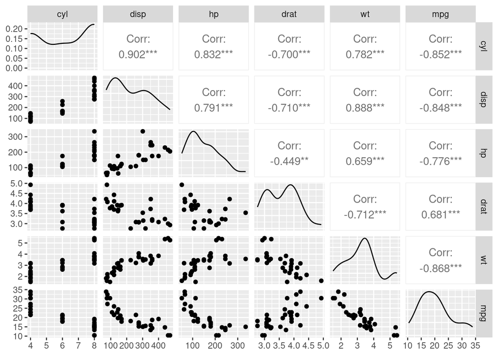

```r
ggpairs(cars, columns = c(2:6,1))
```

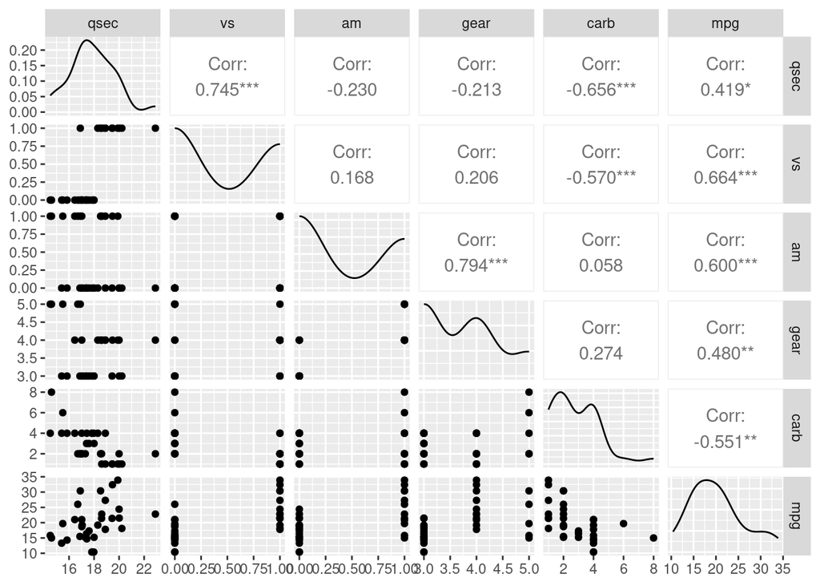

```r
ggpairs(cars, columns = c(7:11,1))
```

### Correlation

Visualization of just correlation.

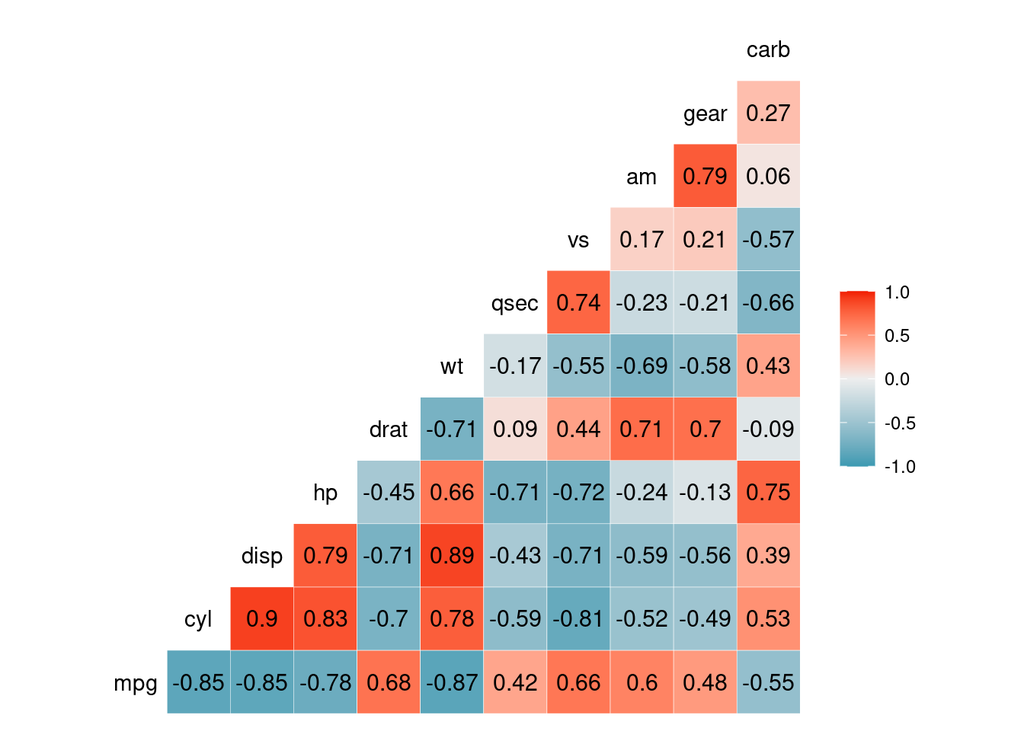

```r
ggcorr(cars, label = TRUE, label_color = "black", label_round = 2)
```

Which variable appears to best predict “mpg”? This variable will have strongest correlation with mpg. Recall that the strongest correlation is closest to 1 or -1.

Looking closer at mpg and wt. What doe this relationship look like?

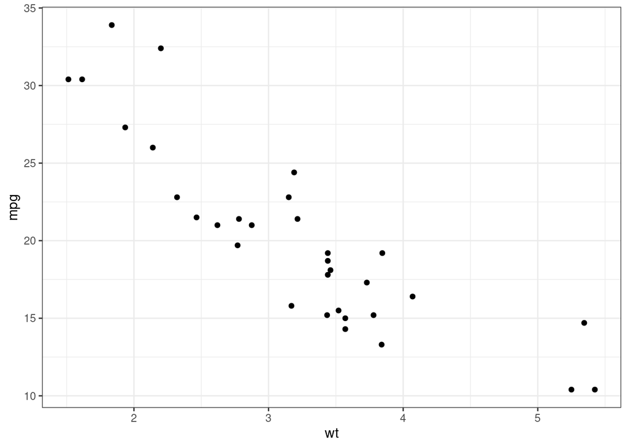

```r
ggplot(cars,aes(x=wt,y=mpg)) + geom_point() + theme_bw()
```

### Build Model(s)

Linear regression: A linear model with one or more “x” (predictor or independent) variables to predict a single “y” (response or dependent) variable. The “y” variable needs to quantitative.

Linear regression assumptions:

- Linear relationship between the x variable(s) and the y variable
- No correlation between consecutive residuals (errors)
- Constant variance of residuals
- Residuals normally distributed

Linear regression model for mpg (using basic R syntax). We’ll use a different framework later for model development that will be more flexible for different model types.

```r
model1 = lm(mpg ~ wt, cars)
summary(model1)
```

```
Call:
lm(formula = mpg ~ wt, data = cars)

Residuals:
    Min      1Q  Median      3Q     Max
-4.5432 -2.3647 -0.1252  1.4096  6.8727

Coefficients:
            Estimate Std. Error t value Pr(>|t|)
(Intercept)  37.2851     1.8776  19.858  < 2e-16 ***
wt           -5.3445     0.5591  -9.559 1.29e-10 ***
---
Signif. codes:  0 '***' 0.001 '**' 0.01 '*' 0.05 '.' 0.1 ' ' 1

Residual standard error: 3.046 on 30 degrees of freedom
Multiple R-squared:  0.7528,    Adjusted R-squared:  0.7446
F-statistic: 91.38 on 1 and 30 DF,  p-value: 1.294e-10
```

What is the regression equation?

mpg = 37.3 - 5.3*wt

37.3 = y intercept

-5.3 = slope

Is weight a significant predictor of mpg?

Is the model good? Look at the R-squared value

### Develop Predictions and Residuals

Let’s visualize the predictions and residuals.

```r
#create a new variable called predicted1 to hold the predictions from model1 and a variable
#called residuals1 to hold the residuals from model1
cars = cars %>% mutate(predicted1 = predict(model1)) %>%
  mutate(residuals1 = residuals(model1))
summary(cars)
```

```
      mpg             cyl             disp             hp
 Min.   :10.40   Min.   :4.000   Min.   : 71.1   Min.   : 52.0
 1st Qu.:15.43   1st Qu.:4.000   1st Qu.:120.8   1st Qu.: 96.5
 Median :19.20   Median :6.000   Median :196.3   Median :123.0
 Mean   :20.09   Mean   :6.188   Mean   :230.7   Mean   :146.7
 3rd Qu.:22.80   3rd Qu.:8.000   3rd Qu.:326.0   3rd Qu.:180.0
 Max.   :33.90   Max.   :8.000   Max.   :472.0   Max.   :335.0
      drat             wt             qsec             vs
 Min.   :2.760   Min.   :1.513   Min.   :14.50   Min.   :0.0000
 1st Qu.:3.080   1st Qu.:2.581   1st Qu.:16.89   1st Qu.:0.0000
 Median :3.695   Median :3.325   Median :17.71   Median :0.0000
 Mean   :3.597   Mean   :3.217   Mean   :17.85   Mean   :0.4375
 3rd Qu.:3.920   3rd Qu.:3.610   3rd Qu.:18.90   3rd Qu.:1.0000
 Max.   :4.930   Max.   :5.424   Max.   :22.90   Max.   :1.0000
       am              gear            carb         predicted1
 Min.   :0.0000   Min.   :3.000   Min.   :1.000   Min.   : 8.297
 1st Qu.:0.0000   1st Qu.:3.000   1st Qu.:2.000   1st Qu.:17.992
 Median :0.0000   Median :4.000   Median :2.000   Median :19.515
 Mean   :0.4062   Mean   :3.688   Mean   :2.812   Mean   :20.091
 3rd Qu.:1.0000   3rd Qu.:4.000   3rd Qu.:4.000   3rd Qu.:23.490
 Max.   :1.0000   Max.   :5.000   Max.   :8.000   Max.   :29.199
   residuals1
 Min.   :-4.5432
 1st Qu.:-2.3647
 Median :-0.1252
 Mean   : 0.0000
 3rd Qu.: 1.4096
 Max.   : 6.8727
```

Plot of data with regression line

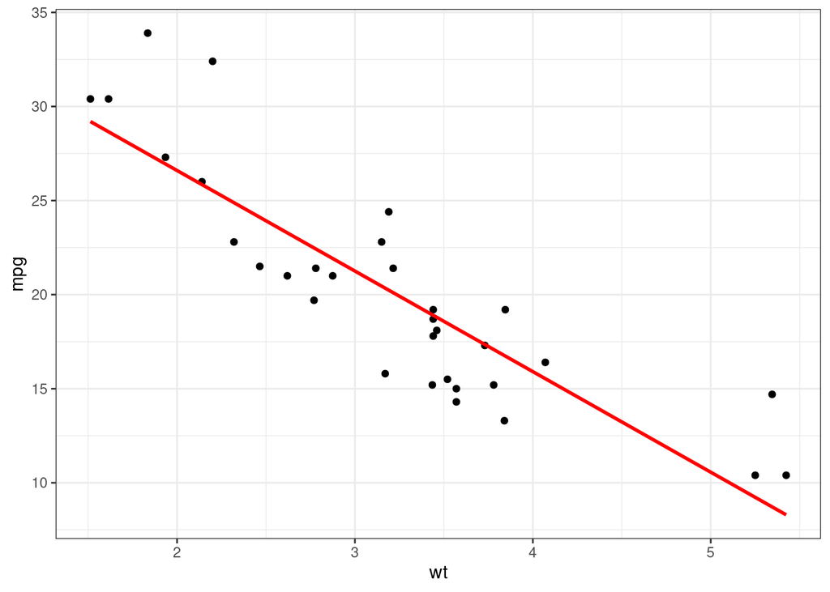

```r
#note use of geom_smooth to add the regression line
ggplot(cars, aes(x = wt, y = mpg)) + geom_point() +
  geom_smooth(method = "lm", se = FALSE, color = "red") + theme_bw()
```

Plot of data, regression line, and residuals.

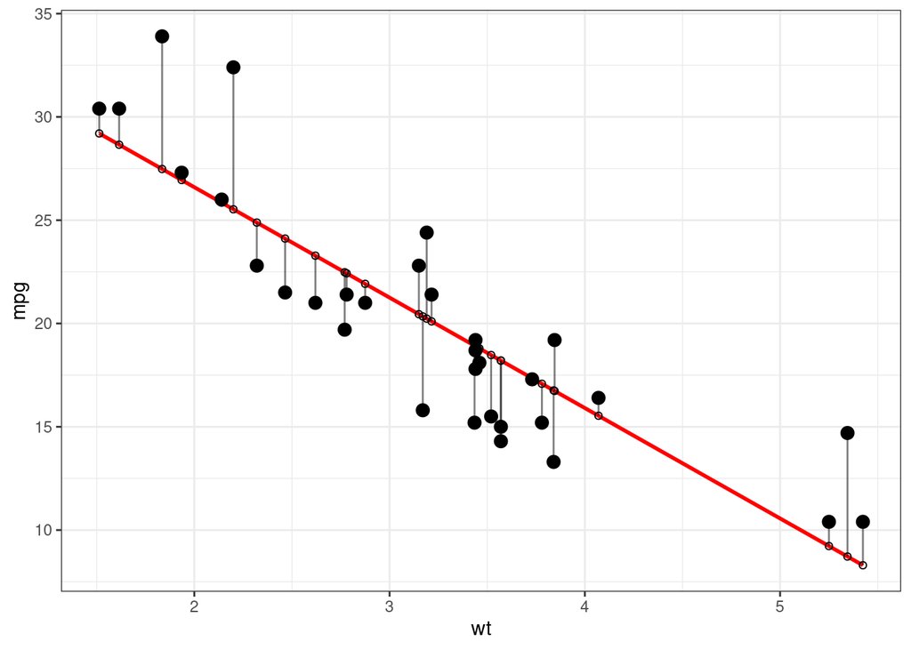

```r
ggplot(cars, aes(x = wt, y = mpg)) +
  geom_smooth(method = "lm", se = FALSE, color = "red") +
  geom_segment(aes(xend = wt, yend = predicted1), alpha = .5) +
  geom_point(size=3) +
  geom_point(aes(y = predicted1), shape = 1) +
  theme_bw()
```

Plot of residuals and wt. This is a diagnostic plot. There should ideally be no visible pattern in the residuals.

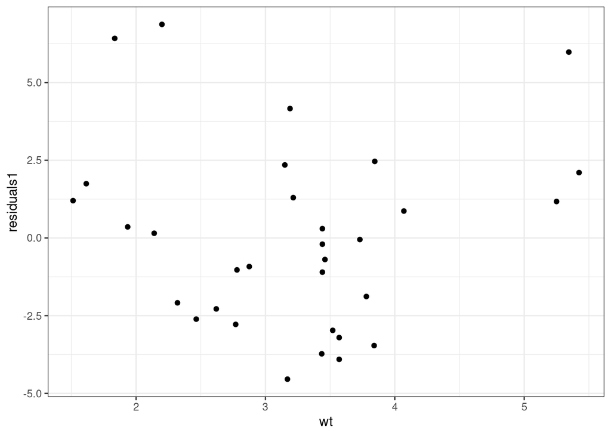

```r
ggplot(cars, aes(x = wt, y = residuals1)) + geom_point() + theme_bw()
```

Do we see a pattern?

Our next diagnostic plot is a histogram of residuals. The residuals should be normally distributed. Note that it will be hard to conclude much of anything from such a small dataset.

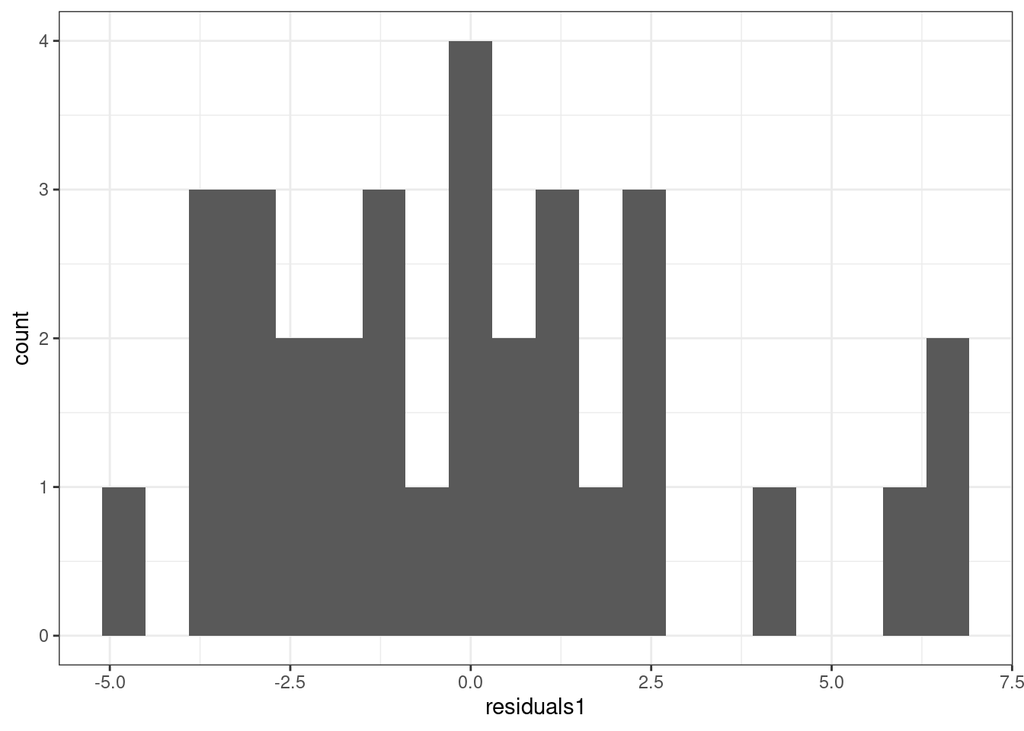

```r
ggplot(cars,aes(x=residuals1)) + geom_histogram(bins=20) + theme_bw()
```

### Looking at a Different Dataset

```r
ames = read_csv("AmesHousing.csv")
```

```r
str(ames)
```

```
spc_tbl_ [2,930 × 8] (S3: spec_tbl_df/tbl_df/tbl/data.frame)
 $ LotArea     : num [1:2930] 31770 11622 14267 11160 13830 ...
 $ OverallQual : num [1:2930] 6 5 6 7 5 6 8 8 8 7 ...
 $ YearBuilt   : num [1:2930] 1960 1961 1958 1968 1997 ...
 $ GrLivArea   : num [1:2930] 1656 896 1329 2110 1629 ...
 $ TotBath     : num [1:2930] 2 1 1.5 3.5 2.5 2.5 3 2 3 2.5 ...
 $ BedroomAbvGr: num [1:2930] 3 2 3 3 3 3 2 2 2 3 ...
 $ Fireplace   : chr [1:2930] "Yes" "No" "No" "Yes" ...
 $ SalePrice   : num [1:2930] 215000 105000 172000 244000 189900 ...
 - attr(*, "spec")=
  .. cols(
  ..   LotArea = col_double(),
  ..   OverallQual = col_double(),
  ..   YearBuilt = col_double(),
  ..   GrLivArea = col_double(),
  ..   TotBath = col_double(),
  ..   BedroomAbvGr = col_double(),
  ..   Fireplace = col_character(),
  ..   SalePrice = col_double()
  .. )
 - attr(*, "problems")=<externalptr>
```

```r
summary(ames)
```

```
    LotArea        OverallQual       YearBuilt      GrLivArea
 Min.   :  1300   Min.   : 1.000   Min.   :1872   Min.   : 334
 1st Qu.:  7440   1st Qu.: 5.000   1st Qu.:1954   1st Qu.:1126
 Median :  9436   Median : 6.000   Median :1973   Median :1442
 Mean   : 10148   Mean   : 6.095   Mean   :1971   Mean   :1500
 3rd Qu.: 11555   3rd Qu.: 7.000   3rd Qu.:2001   3rd Qu.:1743
 Max.   :215245   Max.   :10.000   Max.   :2010   Max.   :5642
    TotBath       BedroomAbvGr    Fireplace           SalePrice
 Min.   :1.000   Min.   :0.000   Length:2930        Min.   : 12789
 1st Qu.:1.500   1st Qu.:2.000   Class :character   1st Qu.:129500
 Median :2.000   Median :3.000   Mode  :character   Median :160000
 Mean   :2.218   Mean   :2.854                      Mean   :180796
 3rd Qu.:2.500   3rd Qu.:3.000                      3rd Qu.:213500
 Max.   :7.000   Max.   :8.000                      Max.   :755000
```

Convert “Fireplace” to a factor as it is categorical (Yes or No). Same with “OverallQual”.

```r
ames = ames %>% mutate(Fireplace = as_factor(Fireplace)) %>%
  mutate(OverallQual = as_factor(OverallQual))
```

Our response variable is “SalePrice”.

Let’s visualize.

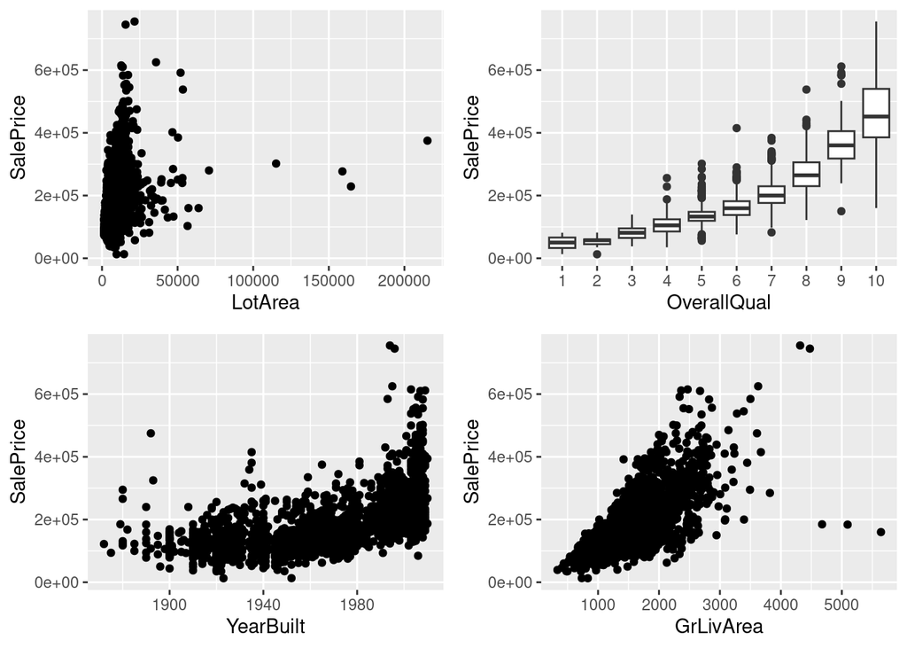

```r
p1 = ggplot(ames,aes(x=LotArea,y=SalePrice)) + geom_point()
p2 = ggplot(ames,aes(x=OverallQual,y=SalePrice)) + geom_boxplot()
p3 = ggplot(ames,aes(x=YearBuilt,y=SalePrice)) + geom_point()
p4 = ggplot(ames,aes(x=GrLivArea,y=SalePrice)) + geom_point()
grid.arrange(p1,p2,p3,p4,ncol=2)
```

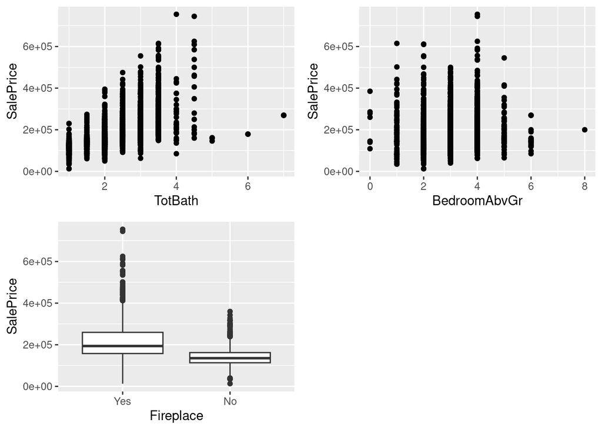

```r
p1 = ggplot(ames,aes(x=TotBath,y=SalePrice)) + geom_point()
p2 = ggplot(ames,aes(x=BedroomAbvGr,y=SalePrice)) + geom_point()
p3 = ggplot(ames,aes(x=Fireplace,y=SalePrice)) + geom_boxplot()
grid.arrange(p1,p2,p3,ncol=2)
```

We could probably do some outlier trimming here.

Let’s look at correlation.

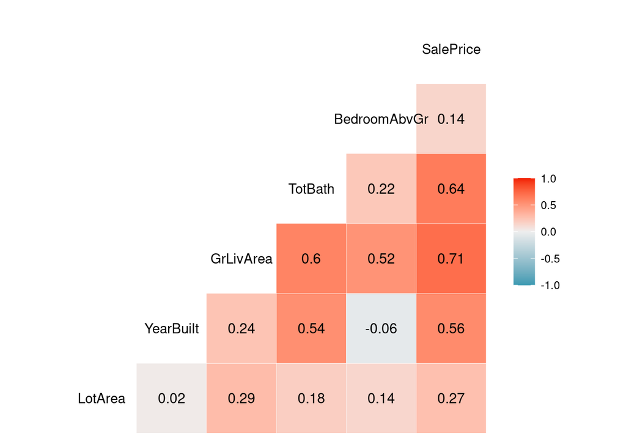

```r
ggcorr(ames, label_round = 2, label = TRUE)
```

Now let’s build a model with the “best” variable to predict “SalePrice.”

```r
model1 = lm(SalePrice ~ GrLivArea, ames)
summary(model1)
```

```
Call:
lm(formula = SalePrice ~ GrLivArea, data = ames)

Residuals:
    Min      1Q  Median      3Q     Max
-483467  -30219   -1966   22728  334323

Coefficients:
             Estimate Std. Error t value Pr(>|t|)
(Intercept) 13289.634   3269.703   4.064 4.94e-05 ***
GrLivArea     111.694      2.066  54.061  < 2e-16 ***
---
Signif. codes:  0 '***' 0.001 '**' 0.01 '*' 0.05 '.' 0.1 ' ' 1

Residual standard error: 56520 on 2928 degrees of freedom
Multiple R-squared:  0.4995,    Adjusted R-squared:  0.4994
F-statistic:  2923 on 1 and 2928 DF,  p-value: < 2.2e-16
```

Is GrLivArea a significant predictor?

Now let’s build a model with the two “best” variables.

```r
#Model here
model2 = lm(SalePrice ~ GrLivArea + TotBath, ames)
summary(model2)
```

```
Call:
lm(formula = SalePrice ~ GrLivArea + TotBath, data = ames)

Residuals:
    Min      1Q  Median      3Q     Max
-428483  -27010   -3016   21167  319269

Coefficients:
              Estimate Std. Error t value Pr(>|t|)
(Intercept) -12610.669   3248.983  -3.881 0.000106 ***
GrLivArea       80.287      2.386  33.642  < 2e-16 ***
TotBath      32914.112   1494.087  22.030  < 2e-16 ***
---
Signif. codes:  0 '***' 0.001 '**' 0.01 '*' 0.05 '.' 0.1 ' ' 1

Residual standard error: 52360 on 2927 degrees of freedom
Multiple R-squared:  0.5707,    Adjusted R-squared:  0.5704
F-statistic:  1946 on 2 and 2927 DF,  p-value: < 2.2e-16
```

We could continue to add variables one at a time, stopping when the model no longer improves.

Build a model with all predictor variables. Note the syntax.

```r
model3 = lm(SalePrice ~., ames)
summary(model3)
```

```
Call:
lm(formula = SalePrice ~ ., data = ames)

Residuals:
    Min      1Q  Median      3Q     Max
-485413  -16053    -387   14241  231497

Coefficients:
                Estimate Std. Error t value Pr(>|t|)
(Intercept)   -8.327e+05  5.770e+04 -14.432  < 2e-16 ***
LotArea        9.262e-01  8.198e-02  11.298  < 2e-16 ***
OverallQual2   2.215e+04  1.893e+04   1.170 0.241952
OverallQual3   3.659e+04  1.736e+04   2.107 0.035188 *
OverallQual4   4.897e+04  1.671e+04   2.930 0.003413 **
OverallQual5   6.431e+04  1.662e+04   3.869 0.000112 ***
OverallQual6   6.976e+04  1.666e+04   4.187 2.91e-05 ***
OverallQual7   8.768e+04  1.672e+04   5.243 1.69e-07 ***
OverallQual8   1.344e+05  1.682e+04   7.990 1.93e-15 ***
OverallQual9   2.115e+05  1.709e+04  12.378  < 2e-16 ***
OverallQual10  2.488e+05  1.797e+04  13.848  < 2e-16 ***
YearBuilt      4.278e+02  2.845e+01  15.035  < 2e-16 ***
GrLivArea      4.968e+01  2.213e+00  22.453  < 2e-16 ***
TotBath        1.056e+04  1.101e+03   9.594  < 2e-16 ***
BedroomAbvGr  -5.544e+03  9.661e+02  -5.738 1.05e-08 ***
FireplaceNo   -1.155e+04  1.442e+03  -8.006 1.69e-15 ***
---
Signif. codes:  0 '***' 0.001 '**' 0.01 '*' 0.05 '.' 0.1 ' ' 1

Residual standard error: 33080 on 2914 degrees of freedom
Multiple R-squared:  0.8294,    Adjusted R-squared:  0.8286
F-statistic: 944.8 on 15 and 2914 DF,  p-value: < 2.2e-16
```

Why are the Fireplace and OverallQual variables treated differently?

#### Stepwise Methods

We can use automated techniques to build regression models. There are a variety of techniques, but the two most popular are: forward and backward stepwise.

**CAUTION**: Using an automated technique can be dangerous. You must still use your intuition about the data. You must still clean and prepare the data. Never blindly accept a model generated by one of these techniques without carefully evaluating it!

Start by building two models: One model that contains all of the predictors and one that is empty.

```r
allmod = lm(SalePrice ~., ames)
summary(allmod)
```

```
Call:
lm(formula = SalePrice ~ ., data = ames)

Residuals:
    Min      1Q  Median      3Q     Max
-485413  -16053    -387   14241  231497

Coefficients:
                Estimate Std. Error t value Pr(>|t|)
(Intercept)   -8.327e+05  5.770e+04 -14.432  < 2e-16 ***
LotArea        9.262e-01  8.198e-02  11.298  < 2e-16 ***
OverallQual2   2.215e+04  1.893e+04   1.170 0.241952
OverallQual3   3.659e+04  1.736e+04   2.107 0.035188 *
OverallQual4   4.897e+04  1.671e+04   2.930 0.003413 **
OverallQual5   6.431e+04  1.662e+04   3.869 0.000112 ***
OverallQual6   6.976e+04  1.666e+04   4.187 2.91e-05 ***
OverallQual7   8.768e+04  1.672e+04   5.243 1.69e-07 ***
OverallQual8   1.344e+05  1.682e+04   7.990 1.93e-15 ***
OverallQual9   2.115e+05  1.709e+04  12.378  < 2e-16 ***
OverallQual10  2.488e+05  1.797e+04  13.848  < 2e-16 ***
YearBuilt      4.278e+02  2.845e+01  15.035  < 2e-16 ***
GrLivArea      4.968e+01  2.213e+00  22.453  < 2e-16 ***
TotBath        1.056e+04  1.101e+03   9.594  < 2e-16 ***
BedroomAbvGr  -5.544e+03  9.661e+02  -5.738 1.05e-08 ***
FireplaceNo   -1.155e+04  1.442e+03  -8.006 1.69e-15 ***
---
Signif. codes:  0 '***' 0.001 '**' 0.01 '*' 0.05 '.' 0.1 ' ' 1

Residual standard error: 33080 on 2914 degrees of freedom
Multiple R-squared:  0.8294,    Adjusted R-squared:  0.8286
F-statistic: 944.8 on 15 and 2914 DF,  p-value: < 2.2e-16
```

```r
emptymod = lm(SalePrice ~1, ames) #use ~1 to build an empty model
summary(emptymod)
```

```
Call:
lm(formula = SalePrice ~ 1, data = ames)

Residuals:
    Min      1Q  Median      3Q     Max
-168007  -51296  -20796   32704  574204

Coefficients:
            Estimate Std. Error t value Pr(>|t|)
(Intercept)   180796       1476   122.5   <2e-16 ***
---
Signif. codes:  0 '***' 0.001 '**' 0.01 '*' 0.05 '.' 0.1 ' ' 1

Residual standard error: 79890 on 2929 degrees of freedom
```

```r
#backward
backmod = stepAIC(allmod, direction = "backward",
                      trace = TRUE) #trace = TRUE shows how the model is built
```

```
Start:  AIC=60998.52
SalePrice ~ LotArea + OverallQual + YearBuilt + GrLivArea + TotBath +
    BedroomAbvGr + Fireplace

               Df  Sum of Sq        RSS   AIC
<none>                       3.1881e+12 60999
- BedroomAbvGr  1 3.6027e+10 3.2241e+12 61029
- Fireplace     1 7.0133e+10 3.2582e+12 61060
- TotBath       1 1.0070e+11 3.2888e+12 61088
- LotArea       1 1.3964e+11 3.3277e+12 61122
- YearBuilt     1 2.4731e+11 3.4354e+12 61215
- GrLivArea     1 5.5155e+11 3.7396e+12 61464
- OverallQual   9 2.2314e+12 5.4195e+12 62535
```

```r
summary(backmod)
```

```
Call:
lm(formula = SalePrice ~ LotArea + OverallQual + YearBuilt +
    GrLivArea + TotBath + BedroomAbvGr + Fireplace, data = ames)

Residuals:
    Min      1Q  Median      3Q     Max
-485413  -16053    -387   14241  231497

Coefficients:
                Estimate Std. Error t value Pr(>|t|)
(Intercept)   -8.327e+05  5.770e+04 -14.432  < 2e-16 ***
LotArea        9.262e-01  8.198e-02  11.298  < 2e-16 ***
OverallQual2   2.215e+04  1.893e+04   1.170 0.241952
OverallQual3   3.659e+04  1.736e+04   2.107 0.035188 *
OverallQual4   4.897e+04  1.671e+04   2.930 0.003413 **
OverallQual5   6.431e+04  1.662e+04   3.869 0.000112 ***
OverallQual6   6.976e+04  1.666e+04   4.187 2.91e-05 ***
OverallQual7   8.768e+04  1.672e+04   5.243 1.69e-07 ***
OverallQual8   1.344e+05  1.682e+04   7.990 1.93e-15 ***
OverallQual9   2.115e+05  1.709e+04  12.378  < 2e-16 ***
OverallQual10  2.488e+05  1.797e+04  13.848  < 2e-16 ***
YearBuilt      4.278e+02  2.845e+01  15.035  < 2e-16 ***
GrLivArea      4.968e+01  2.213e+00  22.453  < 2e-16 ***
TotBath        1.056e+04  1.101e+03   9.594  < 2e-16 ***
BedroomAbvGr  -5.544e+03  9.661e+02  -5.738 1.05e-08 ***
FireplaceNo   -1.155e+04  1.442e+03  -8.006 1.69e-15 ***
---
Signif. codes:  0 '***' 0.001 '**' 0.01 '*' 0.05 '.' 0.1 ' ' 1

Residual standard error: 33080 on 2914 degrees of freedom
Multiple R-squared:  0.8294,    Adjusted R-squared:  0.8286
F-statistic: 944.8 on 15 and 2914 DF,  p-value: < 2.2e-16
```

```r
#forward
forwardmod = stepAIC(emptymod, direction = "forward", scope=list(upper=allmod,lower=emptymod), trace = TRUE)
```

```
Start:  AIC=66150.82
SalePrice ~ 1

               Df  Sum of Sq        RSS   AIC
+ OverallQual   9 1.3127e+13 5.5656e+12 62619
+ GrLivArea     1 9.3376e+12 9.3549e+12 64125
+ TotBath       1 7.5652e+12 1.1127e+13 64633
+ YearBuilt     1 5.8291e+12 1.2863e+13 65058
+ Fireplace     1 4.3327e+12 1.4360e+13 65380
+ LotArea       1 1.3281e+12 1.7364e+13 65937
+ BedroomAbvGr  1 3.8714e+11 1.8305e+13 66091
<none>                       1.8693e+13 66151

Step:  AIC=62619.09
SalePrice ~ OverallQual

               Df  Sum of Sq        RSS   AIC
+ GrLivArea     1 1.4726e+12 4.0930e+12 61721
+ TotBath       1 1.1270e+12 4.4387e+12 61958
+ LotArea       1 5.5657e+11 5.0091e+12 62312
+ Fireplace     1 4.3738e+11 5.1283e+12 62381
+ BedroomAbvGr  1 2.8333e+11 5.2823e+12 62468
+ YearBuilt     1 2.6971e+11 5.2959e+12 62476
<none>                       5.5656e+12 62619

Step:  AIC=61720.6
SalePrice ~ OverallQual + GrLivArea

               Df  Sum of Sq        RSS   AIC
+ YearBuilt     1 4.9367e+11 3.5993e+12 61346
+ TotBath       1 3.7185e+11 3.7211e+12 61444
+ LotArea       1 1.8383e+11 3.9092e+12 61588
+ Fireplace     1 1.2080e+11 3.9722e+12 61635
+ BedroomAbvGr  1 7.5982e+10 4.0170e+12 61668
<none>                       4.0930e+12 61721

Step:  AIC=61346
SalePrice ~ OverallQual + GrLivArea + YearBuilt

               Df  Sum of Sq        RSS   AIC
```

[output cut: 19 more lines]

```
+ Fireplace     1 8.6846e+10 3.2241e+12 61029
+ BedroomAbvGr  1 5.2740e+10 3.2582e+12 61060
<none>                       3.3110e+12 61105

Step:  AIC=61029.44
SalePrice ~ OverallQual + GrLivArea + YearBuilt + LotArea + TotBath +
    Fireplace

               Df  Sum of Sq        RSS   AIC
+ BedroomAbvGr  1 3.6027e+10 3.1881e+12 60999
<none>                       3.2241e+12 61029

Step:  AIC=60998.52
SalePrice ~ OverallQual + GrLivArea + YearBuilt + LotArea + TotBath +
    Fireplace + BedroomAbvGr
```

```r
summary(forwardmod)
```

```
Call:
lm(formula = SalePrice ~ OverallQual + GrLivArea + YearBuilt +
    LotArea + TotBath + Fireplace + BedroomAbvGr, data = ames)

Residuals:
    Min      1Q  Median      3Q     Max
-485413  -16053    -387   14241  231497

Coefficients:
                Estimate Std. Error t value Pr(>|t|)
(Intercept)   -8.327e+05  5.770e+04 -14.432  < 2e-16 ***
OverallQual2   2.215e+04  1.893e+04   1.170 0.241952
OverallQual3   3.659e+04  1.736e+04   2.107 0.035188 *
OverallQual4   4.897e+04  1.671e+04   2.930 0.003413 **
OverallQual5   6.431e+04  1.662e+04   3.869 0.000112 ***
OverallQual6   6.976e+04  1.666e+04   4.187 2.91e-05 ***
OverallQual7   8.768e+04  1.672e+04   5.243 1.69e-07 ***
OverallQual8   1.344e+05  1.682e+04   7.990 1.93e-15 ***
OverallQual9   2.115e+05  1.709e+04  12.378  < 2e-16 ***
OverallQual10  2.488e+05  1.797e+04  13.848  < 2e-16 ***
GrLivArea      4.968e+01  2.213e+00  22.453  < 2e-16 ***
YearBuilt      4.278e+02  2.845e+01  15.035  < 2e-16 ***
LotArea        9.262e-01  8.198e-02  11.298  < 2e-16 ***
TotBath        1.056e+04  1.101e+03   9.594  < 2e-16 ***
FireplaceNo   -1.155e+04  1.442e+03  -8.006 1.69e-15 ***
BedroomAbvGr  -5.544e+03  9.661e+02  -5.738 1.05e-08 ***
---
Signif. codes:  0 '***' 0.001 '**' 0.01 '*' 0.05 '.' 0.1 ' ' 1

Residual standard error: 33080 on 2914 degrees of freedom
Multiple R-squared:  0.8294,    Adjusted R-squared:  0.8286
F-statistic: 944.8 on 15 and 2914 DF,  p-value: < 2.2e-16
```

Since the models are the same, I just chose the forward model as the “champion” model.

Perform model diagnostics. Histogram of residuals and residuals plots (only necessary for quantitative variables)

```r
ames = ames %>% mutate(predforward = predict(forwardmod)) %>%
  mutate(predresid = residuals(forwardmod))
summary(ames)
```

```
    LotArea        OverallQual    YearBuilt      GrLivArea       TotBath
 Min.   :  1300   5      :825   Min.   :1872   Min.   : 334   Min.   :1.000
 1st Qu.:  7440   6      :732   1st Qu.:1954   1st Qu.:1126   1st Qu.:1.500
 Median :  9436   7      :602   Median :1973   Median :1442   Median :2.000
 Mean   : 10148   8      :350   Mean   :1971   Mean   :1500   Mean   :2.218
 3rd Qu.: 11555   4      :226   3rd Qu.:2001   3rd Qu.:1743   3rd Qu.:2.500
 Max.   :215245   9      :107   Max.   :2010   Max.   :5642   Max.   :7.000
                  (Other): 88
  BedroomAbvGr   Fireplace    SalePrice       predforward
 Min.   :0.000   Yes:1508   Min.   : 12789   Min.   : 14417
 1st Qu.:2.000   No :1422   1st Qu.:129500   1st Qu.:128242
 Median :3.000              Median :160000   Median :166179
 Mean   :2.854              Mean   :180796   Mean   :180796
 3rd Qu.:3.000              3rd Qu.:213500   3rd Qu.:212988
 Max.   :8.000              Max.   :755000   Max.   :645413

   predresid
 Min.   :-485413.2
 1st Qu.: -16053.2
 Median :   -386.7
 Mean   :      0.0
 3rd Qu.:  14240.6
 Max.   : 231496.7
```

Histogram of residuals –> Should be normally distributed

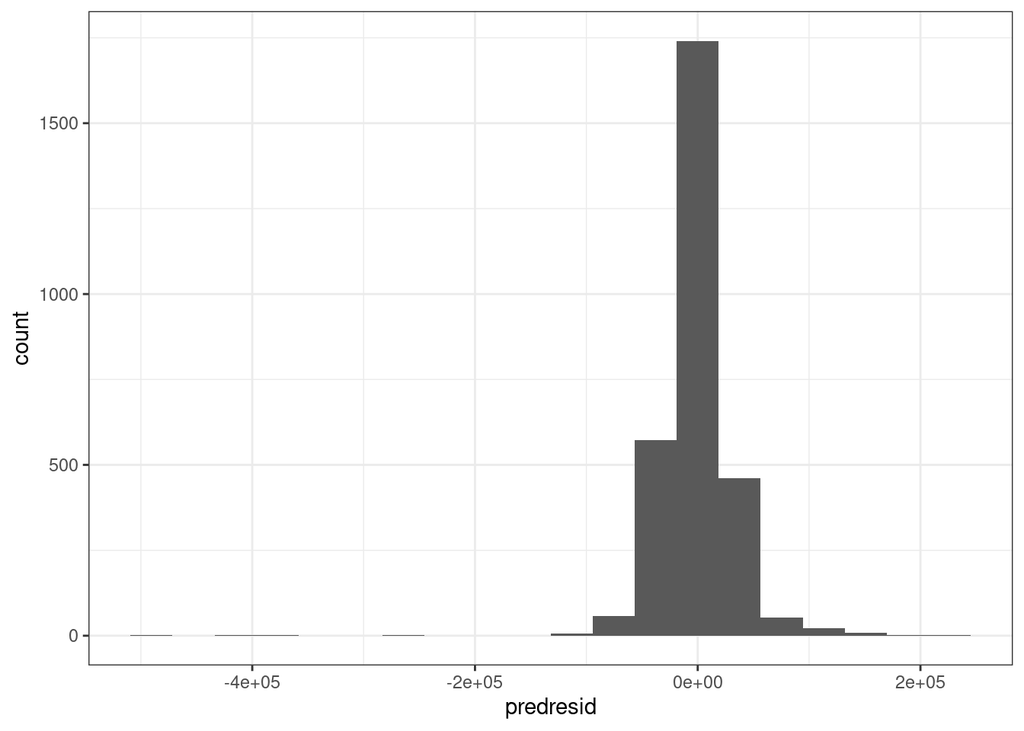

```r
ggplot(ames,aes(x=predresid)) + geom_histogram(bins=20) + theme_bw()
```

Plot of residuals versus each x variable. Doesn’t make much sense to look at categorical variables, but you can.

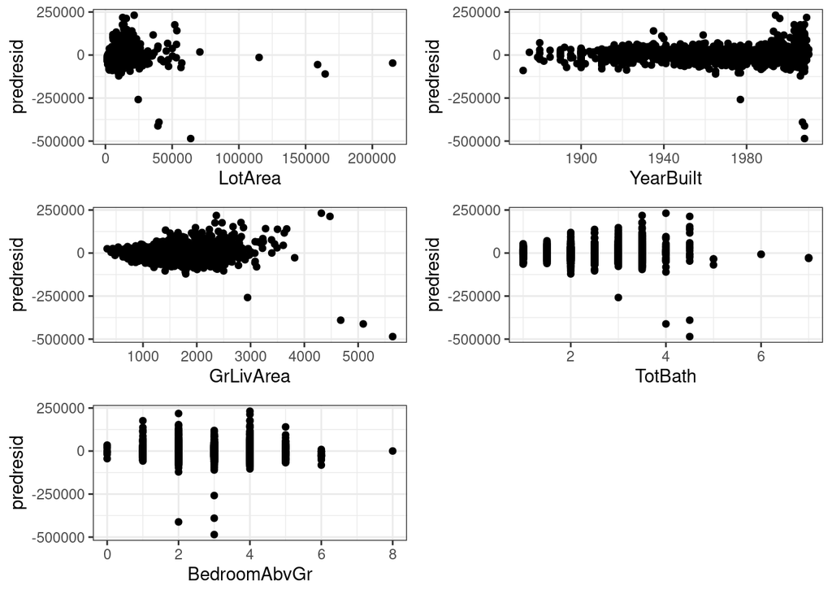

```r
p1 = ggplot(ames, aes(x = LotArea, y = predresid)) + geom_point() + theme_bw()
p2 = ggplot(ames, aes(x = YearBuilt, y = predresid)) + geom_point() + theme_bw()
p3 = ggplot(ames, aes(x = GrLivArea, y = predresid)) + geom_point() + theme_bw()
p4 = ggplot(ames, aes(x = TotBath, y = predresid)) + geom_point() + theme_bw()
p5 = ggplot(ames, aes(x = BedroomAbvGr, y = predresid)) + geom_point() + theme_bw()
grid.arrange(p1,p2,p3,p4,p5,ncol=2)
```

There are definitely some “outlier” residual values. It may be worth eliminating outliers prior to model construction.